# Forest Cover Type Dataset

Stefano Merlo

# 1 Introduction

Scope of this analysis is to develop a model to predict the most present variety of tree for a given area, provided some geographical and terrain characteristics, learning from a 500k observation dataset, using k-nearest neighboor and random forest algorithms.

# 2 Get data and info

## 2.1 Load libraries and data

URL: https://www.kaggle.com/uciml/forest-cover-type-dataset

```r
library(tidyverse)
```

```r
# raw data
raw_data <- readr::read_csv("~/Downloads/forest-trees/covtype.csv", progress = FALSE)
# maintain original raw data and create working dataset
dd <- raw_data %>% tbl_df()
```

## 2.2 Dataset metadata

This dataset is part of the UCI Machine Learning Repository. The original database owners are Jock A. Blackard, Dr. Denis J. Dean, and Dr. Charles W. Anderson of the Remote Sensing and GIS Program at Colorado State University.

It contains tree observations from four areas of the Roosevelt National Forest in Colorado. All observations are cartographic variables (no remote sensing) from 30 meter x 30 meter sections.

Variables:

- Elevation: Elevation in meters
- Aspect: Aspect in degrees azimuth. Aspect is the compass direction that a slope faces.
- Slope: Slope in degrees
- Horizontal Distance To Hydrology: Horz Dist to nearest surface water features
- Vertical Distance To Hydrology: Vert Dist to nearest surface water features
- Horizontal Distance To Roadways: Horz Dist to nearest roadway
- Hillshade 9am (0 to 255 index): Hillshade index at 9am, summer solstice
- Hillshade Noon (0 to 255 index): Hillshade index at noon, summer solstice
- Hillshade 3pm (0 to 255 index): Hillshade index at 3pm, summer solstice
- Horizontal Distance To Fire Points: Horz Dist to nearest wildfire ignition points
- Wilderness Area (4 binary columns, 0 = absence or 1 = presence): Wilderness area designation
- Soil Type (40 binary columns, 0 = absence or 1 = presence): Soil Type designation
- Cover Type (7 types, integers 1 to 7): Forest Cover Type designation

# 3 Exploratory data analysis and metadata reshaping

## 3.1 Explore and uniform variables names and factor levels

```r
names(dd) %>% tbl_df()
```

| value |
| --- |
| Elevation |
| Aspect |
| Slope |
| Horizontal_Distance_To_Hydrology |
| Vertical_Distance_To_Hydrology |
| Horizontal_Distance_To_Roadways |
| Hillshade_9am |
| Hillshade_Noon |
| Hillshade_3pm |
| Horizontal_Distance_To_Fire_Points |

[output cut: 45 more lines]

```r
# remove capitalization and uniform names
names(dd) <- rattle::normVarNames(names(dd))
names(dd) %>% tbl_df()
```

| value |
| --- |
| elevation |
| aspect |
| slope |
| horizontal_distance_to_hydrology |
| vertical_distance_to_hydrology |
| horizontal_distance_to_roadways |
| hillshade_9am |
| hillshade_noon |
| hillshade_3pm |
| horizontal_distance_to_fire_points |

[output cut: 45 more lines]

## 3.2 Convert cover type to factor

```r
cover_types <- tbl_df(data.frame(
    ct = 1:7,
    cover_type = c("Spruce/Fir",
          "Lodgepole Pine",
          "Ponderosa Pine",
          "Cottonwood/Willow",
          "Aspen",
          "Douglas-fir",
          "Krummholz"),
    stringsAsFactors = FALSE
))

# join cover types
dd <- dd %>%
  rename(ct = cover_type) %>%
  left_join(cover_types, by = "ct") %>%
  select(-ct) %>%
  mutate(cover_type = as.factor(cover_type))

# normalize factor levels
levels(dd$cover_type) <- rattle::normVarNames(levels(dd$cover_type))

head(dd$cover_type)
```

```
## [1] aspen          aspen          lodgepole_pine lodgepole_pine
## [5] aspen          lodgepole_pine
## 7 Levels: aspen cottonwood_willow douglas_fir ... spruce_fir
```

## 3.3 Reshape Wide to long

I will convert soil type and wilderness areas, currently in wide format, to long format factors.

```r
wilderness_areas <- tbl_df(data.frame(
    wa = stringr::str_c("wilderness_area_", 1:4),
    wilderness_area = c("Rawah Wilderness Area",
                        "Neota Wilderness Area",
                        "Comanche Peak Wilderness Area",
                        "Cache la Poudre Wilderness Area"),
    stringsAsFactors = FALSE
))

soil_types <- tbl_df(data.frame(
    st = stringr::str_c("soil_type_", 1:40),
    soil_type = c("Cathedral family - Rock outcrop complex, extremely stony",
                  "Vanet - Ratake families complex, very stony",
                  "Haploborolis - Rock outcrop complex, rubbly",
                  "Ratake family - Rock outcrop complex, rubbly",
                  "Vanet family - Rock outcrop complex complex, rubbly",
                  "Vanet - Wetmore families - Rock outcrop complex, stony",
                  "Gothic family",
                  "Supervisor - Limber families complex",
                  "Troutville family, very stony",
                  "Bullwark - Catamount families - Rock outcrop complex, rubbly",
                  "Bullwark - Catamount families - Rock land complex, rubbly.",
                  "Legault family - Rock land complex, stony",
                  "Catamount family - Rock land - Bullwark family complex, rubbly",
                  "Pachic Argiborolis - Aquolis complex",
                  "unspecified in the USFS Soil and ELU Survey",
                  "Cryaquolis - Cryoborolis complex",
                  "Gateview family - Cryaquolis complex",
                  "Rogert family, very stony",
                  "Typic Cryaquolis - Borohemists complex",
                  "Typic Cryaquepts - Typic Cryaquolls complex",
                  "Typic Cryaquolls - Leighcan family, till substratum complex",
                  "Leighcan family, till substratum, extremely bouldery",
                  "Leighcan family, till substratum - Typic Cryaquolls complex",
                  "Leighcan family, extremely stony",
                  "Leighcan family, warm, extremely stony",
                  "Granile - Catamount families complex, very stony",
                  "Leighcan family, warm - Rock outcrop complex, extremely stony",
                  "Leighcan family - Rock outcrop complex, extremely stony",
                  "Como - Legault families complex, extremely stony",
                  "Como family - Rock land - Legault family complex, extremely stony",
                  "Leighcan - Catamount families complex, extremely stony",
                  "Catamount family - Rock outcrop - Leighcan family complex, extremely stony",
                  "Leighcan - Catamount families - Rock outcrop complex, extremely stony",
                  "Cryorthents - Rock land complex, extremely stony",
                  "Cryumbrepts - Rock outcrop - Cryaquepts complex",
                  "Bross family - Rock land - Cryumbrepts complex, extremely stony",
                  "Rock outcrop - Cryumbrepts - Cryorthents complex, extremely stony",
                  "Leighcan - Moran families - Cryaquolls complex, extremely stony",
                  "Moran family - Cryorthents - Leighcan family complex, extremely stony",
                  "Moran family - Cryorthents - Rock land complex, extremely stony"),
    stringsAsFactors = FALSE))

# reshape soil types and convert to labels
dd <- dd %>%
  tidyr::gather(st, st_flag, soil_type_1:soil_type_40) %>%
  filter(st_flag != 0) %>%
  left_join(soil_types, by = "st") %>%
  select(-st, -st_flag) %>%
  mutate(soil_type = as.factor(soil_type))

# reshape wilderness area and convert to labels
dd <- dd %>%
  tidyr::gather(wa, wa_flag, wilderness_area_1:wilderness_area_4) %>%
  filter(wa_flag != 0) %>%
  left_join(wilderness_areas, by = "wa") %>%
  select(-wa, -wa_flag) %>%
  mutate(wilderness_area = as.factor(wilderness_area))
```

## 3.4 Dimensions of the dataset.

```r
dim(dd)
```

```
## [1] 581012     13
```

## 3.5 Target variable

### 3.5.1 Name

```r
# saving name in variable so no need to remember
target <- "cover_type"
```

### 3.5.2 Distribution

```r
knitr::kable(dd %>%
  group_by_(target) %>%
  count() %>%
  arrange(desc(n)) %>%
    mutate(freq = prop.table(n),
           freqcum = cumsum(freq),
           freq = scales::percent(freq),
           freqcum = scales::percent(freqcum),
           n = scales::comma(n)))
```

| cover_type | n | freq | freqcum |
| --- | --- | --- | --- |
| lodgepole_pine | 283,301 | 48.8% | 48.8% |
| spruce_fir | 211,840 | 36.5% | 85.2% |
| ponderosa_pine | 35,754 | 6.2% | 91.4% |
| krummholz | 20,510 | 3.5% | 94.9% |
| douglas_fir | 17,367 | 3.0% | 97.9% |
| aspen | 9,493 | 1.6% | 99.5% |
| cottonwood_willow | 2,747 | 0.5% | 100.0% |

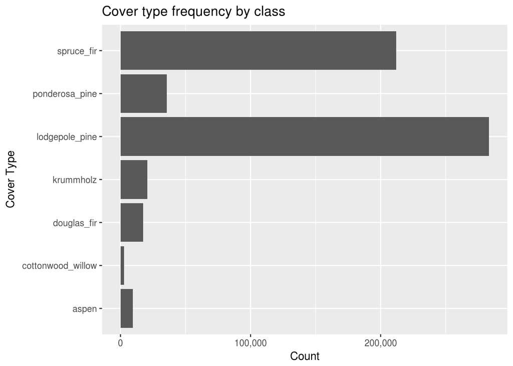

```r
dd %>%
  ggplot(aes_string(x = target)) +
  geom_bar() + coord_flip() +
  scale_y_continuous(labels = scales::comma) +
  labs(x = "Cover Type",
       y = "Count",
       title = "Cover type frequency by class")
```

85% of all observations belogn to two classes only; the other 5 share the remaining 15%.

## 3.6 Variable types

```r
str(dd)
```

```
## Classes 'tbl_df', 'tbl' and 'data.frame':    581012 obs. of  13 variables:
##  $ elevation                         : int  2903 2906 2906 2906 2906 2909 2906 2906 2909 2909 ...
##  $ aspect                            : int  315 45 11 0 333 18 72 0 45 135 ...
##  $ slope                             : int  2 1 4 3 3 2 2 0 1 5 ...
##  $ horizontal_distance_to_hydrology  : int  330 371 360 330 379 360 330 300 390 360 ...
##  $ vertical_distance_to_hydrology    : int  0 6 3 3 6 6 3 3 5 6 ...
##  $ horizontal_distance_to_roadways   : int  4734 4668 4696 4725 4658 4687 4715 4743 4649 4677 ...
##  $ hillshade_9am                     : int  214 219 216 215 212 217 222 218 219 228 ...
##  $ hillshade_noon                    : int  237 236 232 234 235 234 234 238 236 238 ...
##  $ hillshade_3pm                     : int  161 154 153 156 161 154 149 156 154 144 ...
##  $ horizontal_distance_to_fire_points: int  4987 5007 4986 4966 4986 4965 4944 4923 4964 4943 ...
##  $ cover_type                        : Factor w/ 7 levels "aspen","cottonwood_willow",..: 5 5 5 5 5 5 5 5 5 5 ...
##  $ soil_type                         : Factor w/ 40 levels "Bross family - Rock land - Cryumbrepts complex, extremely stony",..: 13 13 13 13 13 13 13 13 13 13 ...
##  $ wilderness_area                   : Factor w/ 4 levels "Cache la Poudre Wilderness Area",..: 4 4 4 4 4 4 4 4 4 4 ...
```

Save indexes of numerical variables is helpful for models that require specific classes as input.

```r
vars <- names(dd)

# indexes of vars candidate inputs for modeling
not_target <- vars[vars != target]
not_target_indexes <- sapply(not_target, function(x) which(x == names(dd)),
                 USE.NAMES = FALSE)

# numerical variables
numeric_vars <- intersect(not_target_indexes,
                          which(sapply(dd, is.numeric)))

# categorical variables
categorical_vars <- intersect(not_target_indexes,
                              which(sapply(dd, is.factor)))
```

## 3.7 Summary for each variable

```r
summary(dd[,not_target])
```

```
##    elevation        aspect          slope
##  Min.   :1859   Min.   :  0.0   Min.   : 0.0
##  1st Qu.:2809   1st Qu.: 58.0   1st Qu.: 9.0
##  Median :2996   Median :127.0   Median :13.0
##  Mean   :2959   Mean   :155.7   Mean   :14.1
##  3rd Qu.:3163   3rd Qu.:260.0   3rd Qu.:18.0
##  Max.   :3858   Max.   :360.0   Max.   :66.0
##
##  horizontal_distance_to_hydrology vertical_distance_to_hydrology
##  Min.   :   0.0                   Min.   :-173.00
##  1st Qu.: 108.0                   1st Qu.:   7.00
##  Median : 218.0                   Median :  30.00
##  Mean   : 269.4                   Mean   :  46.42
##  3rd Qu.: 384.0                   3rd Qu.:  69.00
##  Max.   :1397.0                   Max.   : 601.00
##
##  horizontal_distance_to_roadways hillshade_9am   hillshade_noon
##  Min.   :   0                    Min.   :  0.0   Min.   :  0.0
##  1st Qu.:1106                    1st Qu.:198.0   1st Qu.:213.0
##  Median :1997                    Median :218.0   Median :226.0
##  Mean   :2350                    Mean   :212.1   Mean   :223.3
##  3rd Qu.:3328                    3rd Qu.:231.0   3rd Qu.:237.0
##  Max.   :7117                    Max.   :254.0   Max.   :254.0
##
##  hillshade_3pm   horizontal_distance_to_fire_points
##  Min.   :  0.0   Min.   :   0
##  1st Qu.:119.0   1st Qu.:1024
##  Median :143.0   Median :1710
##  Mean   :142.5   Mean   :1980
##  3rd Qu.:168.0   3rd Qu.:2550
##  Max.   :254.0   Max.   :7173
##
##                                                                       soil_type
##  Como - Legault families complex, extremely stony                          :115247
##  Leighcan family, till substratum - Typic Cryaquolls complex               : 57752
##  Catamount family - Rock outcrop - Leighcan family complex, extremely stony: 52519
##  Leighcan - Catamount families - Rock outcrop complex, extremely stony     : 45154
##  Leighcan family, till substratum, extremely bouldery                      : 33373
##  Bullwark - Catamount families - Rock outcrop complex, rubbly              : 32634
##  (Other)                                                                   :244333
##                         wilderness_area
##  Cache la Poudre Wilderness Area: 36968
##  Comanche Peak Wilderness Area  :253364
##  Neota Wilderness Area          : 29884
##  Rawah Wilderness Area          :260796
##
##
##
```

There are no missing values or bad records.

We can notice that the elevation is remarkably high in all observations, and the average slope is 14 degrees.

## 3.8 Variables classes

```r
sapply(dd, class)
```

```
##                          elevation                             aspect
##                          "integer"                          "integer"
##                              slope   horizontal_distance_to_hydrology
##                          "integer"                          "integer"
##     vertical_distance_to_hydrology    horizontal_distance_to_roadways
##                          "integer"                          "integer"
##                      hillshade_9am                     hillshade_noon
##                          "integer"                          "integer"
##                      hillshade_3pm horizontal_distance_to_fire_points
##                          "integer"                          "integer"
##                         cover_type                          soil_type
##                           "factor"                           "factor"
##                    wilderness_area
##                           "factor"
```

All variables have appropriate classes.

## 3.9 Check for highly correlated variables

```r
mc <- cor(dd[which(sapply(dd, is.numeric))], use = "complete.obs")
mc[upper.tri(mc, diag = TRUE)] <- NA
mc %>%
  abs() %>%
  data.frame %>%
  tbl_df() %>%
  mutate(var1 = row.names(mc)) %>%
  gather(var2, cor, -var1) %>%
  na.omit() %>%
  arrange(desc(cor)) %>%
  filter(cor > 0.5) %>%
  knitr::kable(digits = 3)
```

| var1 | var2 | cor |
| --- | --- | --- |
| hillshade_3pm | hillshade_9am | 0.780 |
| hillshade_3pm | aspect | 0.647 |
| vertical_distance_to_hydrology | horizontal_distance_to_hydrology | 0.606 |
| hillshade_3pm | hillshade_noon | 0.594 |
| hillshade_9am | aspect | 0.579 |
| hillshade_noon | slope | 0.527 |

Highest correlation is between hillshade in the morning and in the afternoon, likely in areas where the sun is blocked by natural barriers only in certain periods of the day.

Same for hillshade and aspect: this is also expected by the definition of the variables: * aspect is the compass direction that a slope faces; * hillshade is an index for the illumination on summer solstice

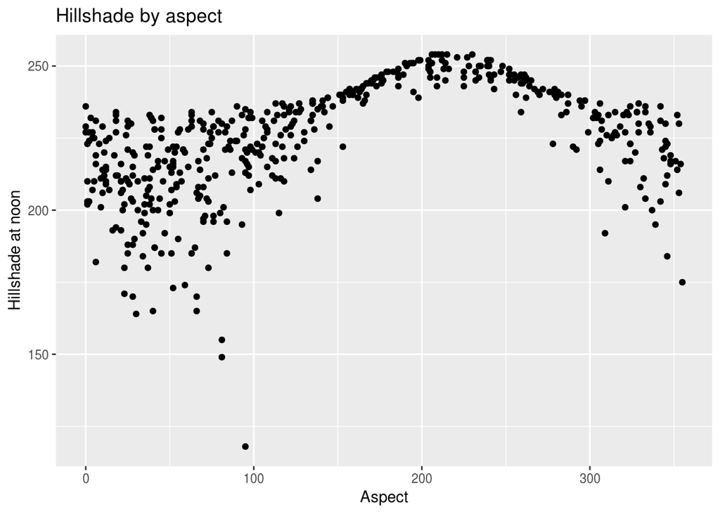

```r
dd %>%
  sample_n(500) %>%
  ggplot(aes(x = aspect, y = hillshade_noon)) +
  geom_point() +
  labs(x = "Aspect", y = "Hillshade at noon", title = "Hillshade by aspect")
```

When the aspect is around 180, so south-facing, the hillshade is maximun: this is correct since these wilderness areas are in the northern emisphere.

# 4 Data visualization

## 4.1 Elevation

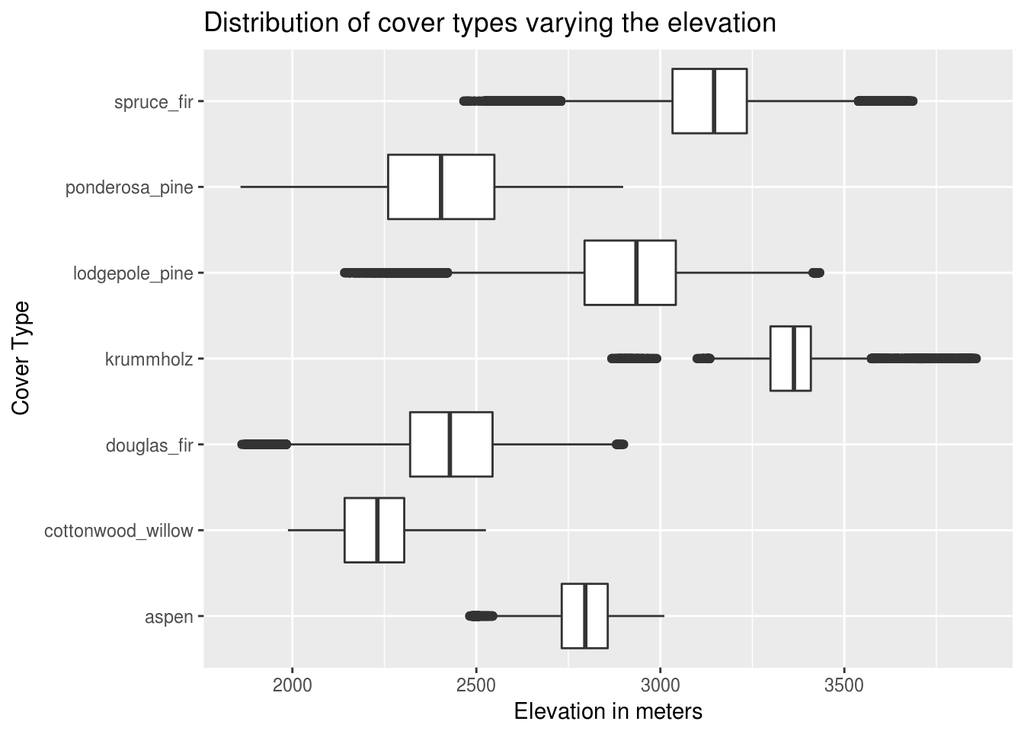

```r
dd %>%
  ggplot(aes_string(x = target, y = "elevation")) +
  geom_boxplot() +
  coord_flip() +
  labs(x = "Cover Type",
       y = "Elevation in meters",
       title = "Distribution of cover types varying the elevation")
```

This looks a good predictor.

## 4.2 Slope

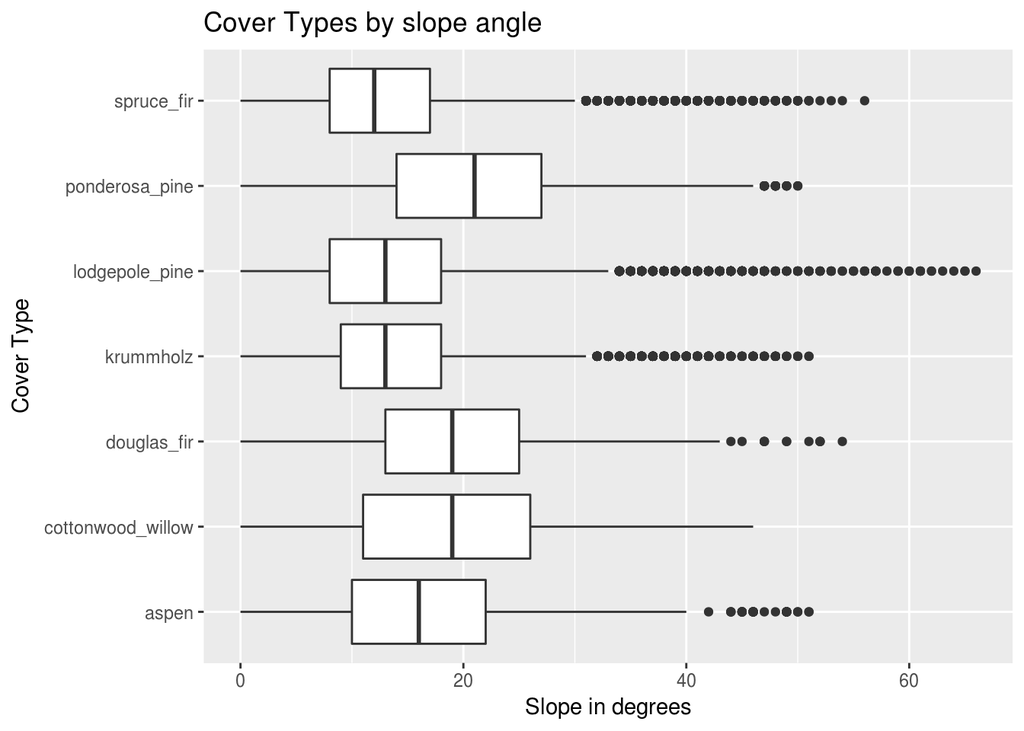

```r
dd %>%
  ggplot(aes_string(x = target, y = "slope")) +
  geom_boxplot() +
  coord_flip() +
  labs(x = "Cover Type",
       y = "Slope in degrees",
       title = "Cover Types by slope angle")
```

Looks like a bad predictor.

## 4.3 Aspect

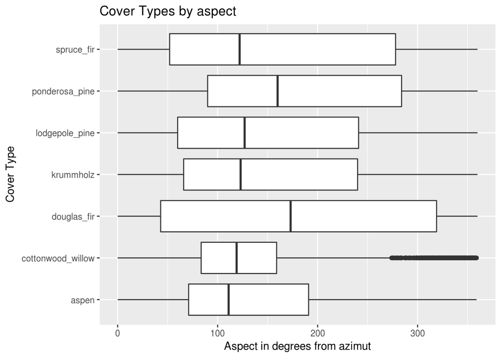

```r
dd %>%
  ggplot(aes_string(x = target, y = "aspect")) +
  geom_boxplot() +
  coord_flip() +
  labs(x = "Cover Type",
       y = "Aspect in degrees from azimut",
       title = "Cover Types by aspect")
```

Aspect looks like a very bad predictor.

## 4.4 Hillshades

There are three different hillshade values, taken at three times of day.

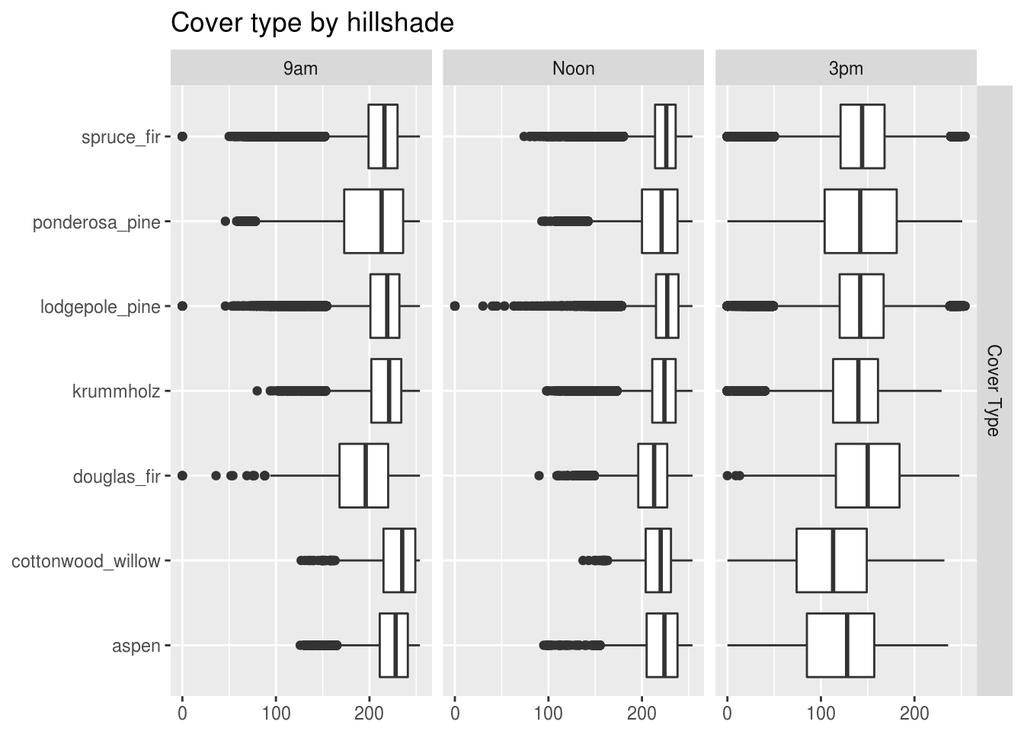

```r
# list of plots at all times of the day
plot_list <- list()
plot_list[[1]] <- dd %>%
  ggplot(aes_string(x = target, y = "hillshade_9am")) +
  geom_boxplot() + coord_flip()
plot_list[[2]] <- dd %>%
  ggplot(aes_string(x = target, y = "hillshade_noon")) +
  geom_boxplot() + coord_flip()
plot_list[[3]] <- dd %>%
  ggplot(aes_string(x = target, y = "hillshade_3pm")) +
  geom_boxplot() + coord_flip()

# plot all plots in a grid
GGally::ggmatrix(plot_list,
                 nrow = 1,
                 ncol = 3,
                 xAxisLabels = c("9am", "Noon", "3pm"),
                 yAxisLabels = "Cover Type",
                 title = "Cover type by hillshade")
```

Taken separately don’t seem a strong features, but I will try to create a new one by multiplying.

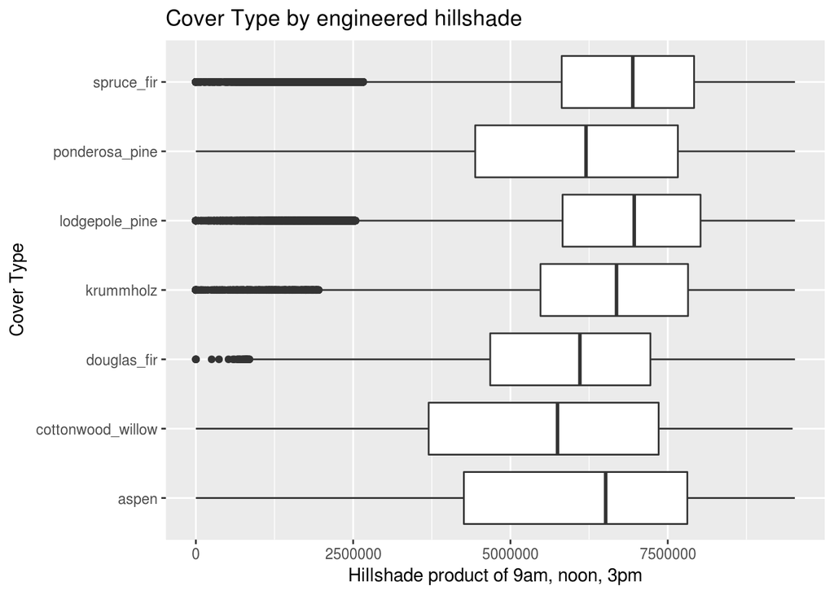

```r
dd <- dd %>%
    mutate(hillshade_tot = hillshade_9am * hillshade_noon * hillshade_3pm)
dd %>%
  ggplot(aes_string(x = target, y = "hillshade_tot")) +
  geom_boxplot() +
  coord_flip() +
  labs(x = "Cover Type",
       y = "Hillshade product of 9am, noon, 3pm",
       title = "Cover Type by engineered hillshade")
```

Slightly better but still a weak predictor.

## 4.5 Distance to hydrology

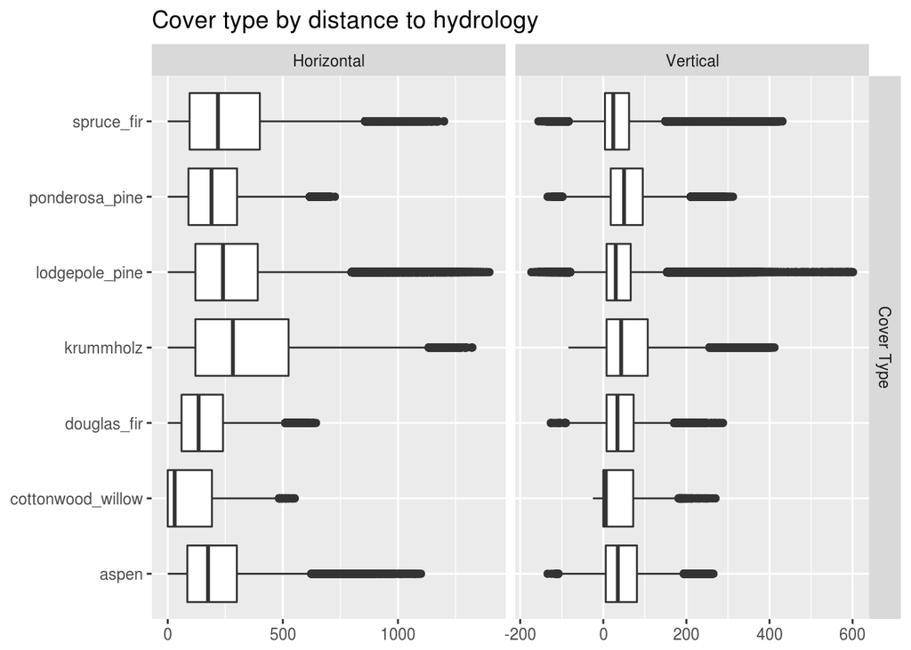

```r
# list of plots
plot_list <- list()
plot_list[[1]] <- dd %>%
  ggplot(aes_string(x = target, y = "horizontal_distance_to_hydrology")) +
  geom_boxplot() + coord_flip()
plot_list[[2]] <- dd %>%
  ggplot(aes_string(x = target, y = "vertical_distance_to_hydrology")) +
  geom_boxplot() + coord_flip()

# plot all plots in a grid
GGally::ggmatrix(plot_list,
                 nrow = 1,
                 ncol = 2,
                 xAxisLabels = c("Horizontal", "Vertical"),
                 yAxisLabels = "Cover Type",
                 title = "Cover type by distance to hydrology")
```

Poor predictor. I will combine horizontal and vertical distances in an unique variable

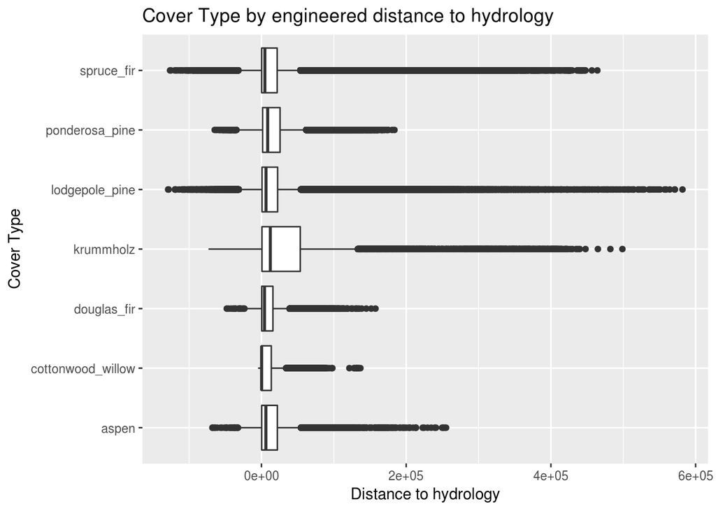

```r
dd <- dd %>%
    mutate(distance_to_hydrology = horizontal_distance_to_hydrology * vertical_distance_to_hydrology)
dd %>%
  ggplot(aes_string(x = target, y = "distance_to_hydrology")) +
  geom_boxplot() +
  coord_flip() +
  labs(x = "Cover Type",
       y = "Distance to hydrology",
       title = "Cover Type by engineered distance to hydrology")
```

Even worse.

# 5 Data Modeling

I will use the following models:

- random forest
- k-nearest neighboors

I will first run algorithms on a small subset, to have a look at how they perform before applying to the whole dataset.

## 5.1 Modelling on a micro subset

### 5.1.1 Subset dataset

```r
set.seed(12)
in_micro <- caret::createDataPartition(dd[, target][[1]],
                                         p = 0.01,
                                         list = FALSE)
dd_micro <- dd[in_micro, ]
```

### 5.1.2 Create train / test

```r
in_train <- caret::createDataPartition(dd_micro[, target][[1]],
                                       p = 0.80,
                                       list = FALSE)
train_micro <- dd_micro[in_train, ]
test_micro <- dd_micro[-in_train, ]
```

## 5.2 Random forest.

```r
set.seed(12)

# find best mtry
b <- randomForest::tuneRF(train_micro[, not_target],
                          train_micro[,target][[1]],
                          ntreeTry = 100)
```

```
## mtry = 3  OOB error = 27.3%
## Searching left ...
## mtry = 2     OOB error = 28.25%
## -0.03461841 0.05
## Searching right ...
## mtry = 6     OOB error = 27.86%
## -0.02045633 0.05
```

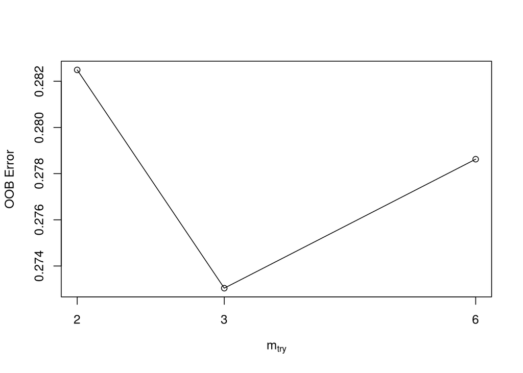

```r
best_mtry <- b[which(b[,2] == min(b[,2])), 1]

# create model
rf_micro <- randomForest::randomForest(x = train_micro[, not_target],
                                       y = train_micro[,target][[1]],
                                       mtry = best_mtry,
                                       ntree = 100,
                                       importance = TRUE,
                                       keep.forest = TRUE)

# accuracy
rf_micro_pred <- predict(rf_micro,
                         newdata = test_micro,
                         type = "class")

rf_cm_micro <-  caret::confusionMatrix(rf_micro_pred, test_micro[, target][[1]])
paste("Random forest model accuracy, partial dataset:",
      scales::percent(rf_cm_micro$overall["Accuracy"]))
```

```
## [1] "Random forest model accuracy, partial dataset: 72.7%"
```

## 5.3 KNN

```r
set.seed(12)

# find best k
best_k <- fastknn::fastknnCV(as.matrix(train_micro[, numeric_vars]),
                             train_micro[, target][[1]],
                             k = 3:15,
                             method = "vote",
                             folds = 5,
                             eval.metric = "overall_error")
# predict using the best k
knn_micro_pred <- fastknn::fastknn(as.matrix(train_micro[, numeric_vars]),
                 train_micro[, target][[1]],
                 as.matrix(test_micro[, numeric_vars]),
                 k = best_k$best_k)

# accuracy
knn_micro_acc <- 1 - fastknn::classLoss(actual = test_micro[, target][[1]],
                                        predicted = knn_micro_pred$class)
paste("KNN accuracy, partial dataset:",
      scales::percent(knn_micro_acc))
```

```
## [1] "KNN accuracy, partial dataset: 73%"
```

## 5.4 Entire dataset

### 5.4.1 Create train / test

```r
in_train <- caret::createDataPartition(dd[, target][[1]],
                                       p = 0.80,
                                       list = FALSE)
train_full <- dd[in_train, ]
test_full <- dd[-in_train, ]
```

## 5.5 Random forest.

```r
set.seed(12)

# find best mtry
b <- randomForest::tuneRF(train_full[, not_target],
                          train_full[,target][[1]],
                          ntreeTry = 100)
```

```
## mtry = 3  OOB error = 17.11%
## Searching left ...
## mtry = 2     OOB error = 16.99%
## 0.007064739 0.05
## Searching right ...
## mtry = 6     OOB error = 18.19%
## -0.06274041 0.05
```

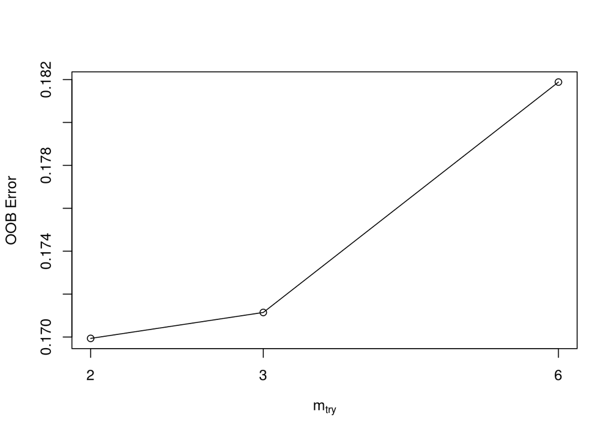

```r
best_mtry <- b[which(b[,2] == min(b[,2])), 1]

# create model
rf_full <- randomForest::randomForest(x = train_full[, not_target],
                                       y = train_full[,target][[1]],
                                       mtry = best_mtry,
                                       ntree = 100,
                                       importance = TRUE,
                                       keep.forest = TRUE)

# accuracy
rf_full_pred <- predict(rf_full,
                         newdata = test_full,
                         type = "class")

rf_cm_full <-  caret::confusionMatrix(rf_full_pred, test_full[, target][[1]])
paste("Random forest model accuracy, full dataset:",
      rf_cm_full$overall["Accuracy"])
```

[output not shown]

## 5.6 KNN

```r
set.seed(12)

# find best k
best_k <- fastknn::fastknnCV(as.matrix(train_full[, numeric_vars]),
                             train_full[, target][[1]],
                             k = 3:15,
                             method = "vote",
                             folds = 5,
                             eval.metric = "overall_error")
# predict using the best k
knn_full_pred <- fastknn::fastknn(as.matrix(train_full[, numeric_vars]),
                 train_full[, target][[1]],
                 as.matrix(test_full[, numeric_vars]),
                 k = best_k$best_k)

# accuracy
knn_full_acc <- 1 - fastknn::classLoss(actual = test_full[, target][[1]],
                                       predicted = knn_full_pred$class)
paste("KNN accuracy, full dataset:", scales::percent(knn_full_acc))
```

```
## [1] "KNN accuracy, full dataset: 97%"
```

# 6 Ackowledgements

- Hands on Data Science tutorials by Graham Williams, http://handsondatascience.com/DataO.pdf